# Autogenous - quality control.

Luciano V Cosme

2026-04-05

> **Population label key:** The code labels used in the analysis below correspond to the following manuscript labels: AUT = AUTO, MAN = NON-AUTO, NEW = NON-AUTO-FIELD.

## 1. Getting started: R libraries and software for QC

## 1.1 R libraries and software

```r
library(tidyverse)
library(here)
library(scales)
library(RColorBrewer)
library(ggrepel)
library(adegenet)

source(here("notebooks", "helpers", "my_theme2.R"))
source(here("notebooks", "helpers", "import_bim.R"))
```

## 1.2 Software

All analyses were performed inside a reproducible container (`ghcr.io/cosmelab/albopictus-autogeny:latest`) with PLINK 1.9, PLINK 2, bcftools, samtools, bedtools, snpEff, and R 4.2. See the Dockerfile and pixi.toml for the full dependency list.

Quality control follows the general guidelines of [Marees et al. (2018)](https://doi.org/10.1002/mpr.1608).

## 2. The data

The data was prepared with family and individual IDs assigned, and reference alleles set to match the AalbF3 genome assembly.

```bash
bcftools query -l data/genotype_calls/autogenous.vcf | wc -l
```

```
## 61
```

## 2.1 Use Plink2 to convert to bed format

```bash
plink2 \
--allow-extra-chr \
--vcf data/genotype_calls/autogenous.vcf \
--const-fid \
--make-bed \
--exclude data/files/albopictus_SNPs_fail_segregation.txt \
--fa data/genome/albo.fasta.gz \
--ref-from-fa 'force' `# sets REF alleles when it can be done unambiguously, we use force to change the alleles` \
--out output/quality_control/file1 \
--silent;
grep "variants" output/quality_control/file1.log
```

```
## --vcf: 131048 variants scanned.
## 131048 variants loaded from output/quality_control/file1-temporary.pvar.zst.
## --exclude: 129381 variants remaining.
## 129381 variants remaining after main filters.
## --ref-from-fa force: 0 variants changed, 129381 validated.
```

## 2.2 Use R to update the .fam file

Sample metadata was imported to update the `.fam` file with population assignments.

```r
samples <-
  read.delim(
    file   = here(
      "data",
      "files",
      "meta_data.txt"
    ),
    header = TRUE
  )
head(samples)
```

```
##   Sample.Filename Family_ID Individual_ID Father_ID Mother_ID Sex
## 1 306_MAN_USA.CEL       MAN           306         0         0   0
## 2 307_MAN_USA.CEL       MAN           307         0         0   0
## 3 308_MAN_USA.CEL       MAN           308         0         0   0
## 4 309_MAN_USA.CEL       MAN           309         0         0   0
## 5 310_MAN_USA.CEL       MAN           310         0         0   0
## 6 311_MAN_USA.CEL       MAN           311         0         0   0
##   Affection.Status
## 1               -9
## 2               -9
## 3               -9
## 4               -9
## 5               -9
## 6               -9
```

```r
fam1 <-
  read.delim(
    file   = here(
      "output", "quality_control", "file1.fam"
    ),
    header = FALSE,

  )
head(fam1)
```

```
##   V1              V2 V3 V4 V5 V6
## 1  0 306_MAN_USA.CEL  0  0  0 -9
## 2  0 307_MAN_USA.CEL  0  0  0 -9
## 3  0 308_MAN_USA.CEL  0  0  0 -9
## 4  0 309_MAN_USA.CEL  0  0  0 -9
## 5  0 310_MAN_USA.CEL  0  0  0 -9
## 6  0 311_MAN_USA.CEL  0  0  0 -9
```

```r
# Extract the number part from the columns
fam1_temp <- fam1 |>
  mutate(num_id = as.numeric(str_extract(V2, "^\\d+")))

samples_temp <- samples |>
  mutate(num_id = as.numeric(str_extract(Sample.Filename, "^\\d+")))

# Perform the left join using the num_id columns and keep the order of fam1
df <- fam1_temp |>
  dplyr::left_join(samples_temp, by = "num_id") |>
  dplyr::select(-num_id) |>
  dplyr::select(8:13)

head(df)
```

```
##   Family_ID Individual_ID Father_ID Mother_ID Sex Affection.Status
## 1       MAN           306         0         0   0               -9
## 2       MAN           307         0         0   0               -9
## 3       MAN           308         0         0   0               -9
## 4       MAN           309         0         0   0               -9
## 5       MAN           310         0         0   0               -9
## 6       MAN           311         0         0   0               -9
```

```r
nrow(df)
```

```
## [1] 61
```

The original `.fam` is overwritten with updated metadata.

```r
# Update .fam with sample metadata
write.table(
  df,
  file      = here(
    "output", "quality_control", "file1.fam"
  ),
  sep       = "\t",
  row.names = FALSE,
  col.names = FALSE,
  quote     = FALSE
)
```

## 2.3 Checking the number of samples and localities

```bash
awk '{print $1}' output/quality_control/file1.fam | sort | uniq -c | awk '{print $2, $1}'
```

```
## AUT 29
## MAN 10
## NEW 22
```

## 3. Quality control steps

## 3.1 Missingness

```bash
plink2 \
--allow-extra-chr \
--bfile output/quality_control/file1 \
--geno 0.2                `# we set genotype missiningness to 20% with this option` \
--make-bed \
--out output/quality_control/file2 \
--silent \
--missing;                 # --missing produces sample-based and variant-based missing data reports. If run with --within/--family, the variant-based report is stratified by cluster.
grep "variants" output/quality_control/file2.log
```

```
## 129381 variants loaded from output/quality_control/file1.bim.
## --geno: 2271 variants removed due to missing genotype data.
## 127110 variants remaining after main filters.
```

```r
indmiss <-
  read.delim(
    file   = here(
      "output", "quality_control", "file2.smiss"
    ),
    header = TRUE
  )

snpmiss <-
  read.delim(
    file   = here(
      "output", "quality_control", "file2.vmiss"
    ),
    header = TRUE
  )
```

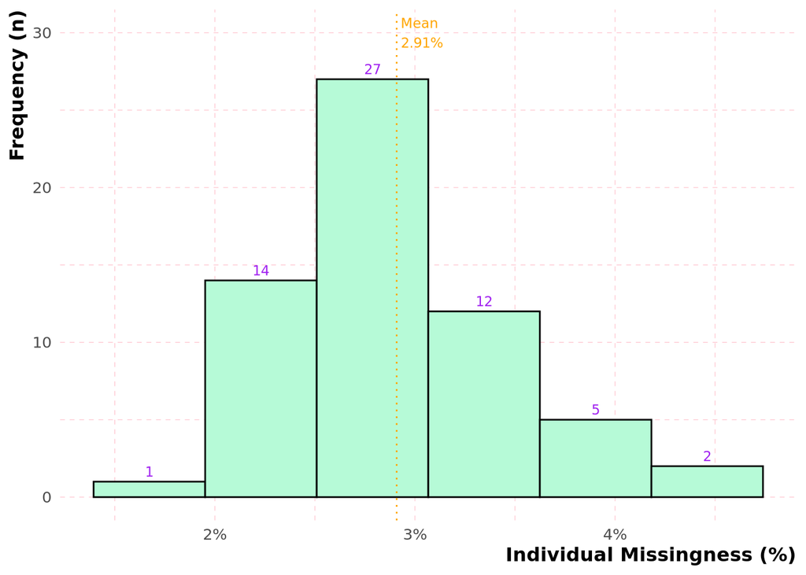

```r
ggplot(
  indmiss,
  aes(
    x = F_MISS
  )
) +
  geom_histogram(
    color            = "black",
    fill             = "#B6FAD7",
    bins             = 6
  ) +
  geom_text(
    stat             = "bin",
    aes(
    label = after_stat(count)
  ),
    vjust            = -0.5,
    color            = "purple",
    size             = 3,
    bins             = 6
  ) +
  geom_vline(
    aes(
    xintercept = mean(F_MISS)),
    color            = "orange",
    linetype         = "dotted",
    linewidth        = .5
  ) +
  annotate(
    "text",
    x = mean(indmiss$F_MISS),
    y = 30,
    label = paste0(
      "Mean \n",
      scales::percent(mean(indmiss$F_MISS),
        accuracy = 0.01
      )
    ),
    size = 3,
    color = "orange",
    hjust = -.1
  ) +
  labs(
    x                = "Individual Missingness (%)",
    y                = "Frequency (n)"
  ) +
  my_theme() +
  scale_x_continuous(
    labels           = scales::percent,
    n.breaks         = 6
  )
```

```r
ggsave(
  here(
    "output", "quality_control", "figures" , "individual_missingness.pdf"
  ),
  width              = 7,
  height             = 5,
  units              = "in"
)
```

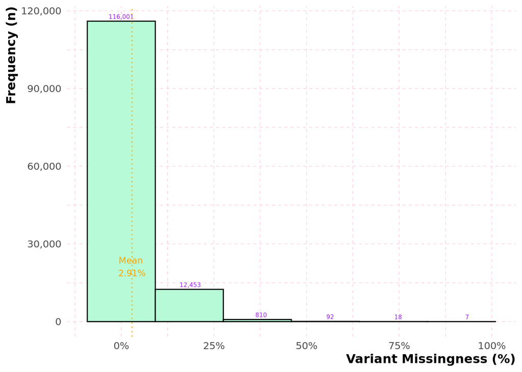

```r
ggplot(
  snpmiss,
  aes(
    x = F_MISS
  )
) +
  geom_histogram(
    color = "black",
    fill = "#B6FAD7",
    bins = 6
  ) +
  stat_bin(
    geom = "text",
    aes(
      label = format(
        after_stat(count),
        big.mark = ",",
        scientific = FALSE
      )
    ),
    vjust = -0.5,
    color = "purple",
    size = 2,
    bins = 6
  ) +
  geom_vline(
    aes(
      xintercept = mean(F_MISS)
    ),
    color = "orange",
    linetype = "dotted",
    linewidth = 0.5
  ) +
  annotate(
    "text",
    x = mean(snpmiss$F_MISS),
    y = 16000,
    label = paste0(
      "Mean \n",
      scales::percent(mean(snpmiss$F_MISS),
        accuracy = 0.01
      )
    ),
    size = 3,
    color = "orange",
    vjust = -.2
  ) +
  labs(
    x = "Variant Missingness (%)",
    y = "Frequency (n)"
  ) +
  scale_x_continuous(
    labels = scales::percent,
    n.breaks = 6
  ) +
  scale_y_continuous(
    labels = scales::label_comma(),
    n.breaks = 5
  ) +
  my_theme()
```

```r
ggsave(
  here(
    "output", "quality_control", "figures", "SNPs_missingness.pdf"
  ),
  width  = 7,
  height = 5,
  units  = "in"
)
```

Individuals with >20% missing genotypes were removed.

```bash
plink2 \
--allow-extra-chr \
--bfile output/quality_control/file2 \
--mind 0.2               `# here we set the individual missingness threshold of 20%`\
--make-bed \
--out output/quality_control/file3 \
--silent;
grep "samples\|variants" output/quality_control/file3.log
```

```
## 61 samples (25 females, 26 males, 10 ambiguous; 61 founders) loaded from
## 127110 variants loaded from output/quality_control/file2.bim.
## 0 samples removed due to missing genotype data (--mind).
## 61 samples (25 females, 26 males, 10 ambiguous; 61 founders) remaining after
```

No individuals were removed due to missingness.

## 3.2 Minor allele frequency

Allele frequency distribution was estimated with PLINK2.

```bash
plink2 \
--allow-extra-chr \
--bfile output/quality_control/file3 \
--freq \
--out output/quality_control/MAF_check \
--silent
```

```r
maf_freq <-
  read.delim(
    here(
      "output", "quality_control", "MAF_check.afreq"
    ),
    header = TRUE
  )
```

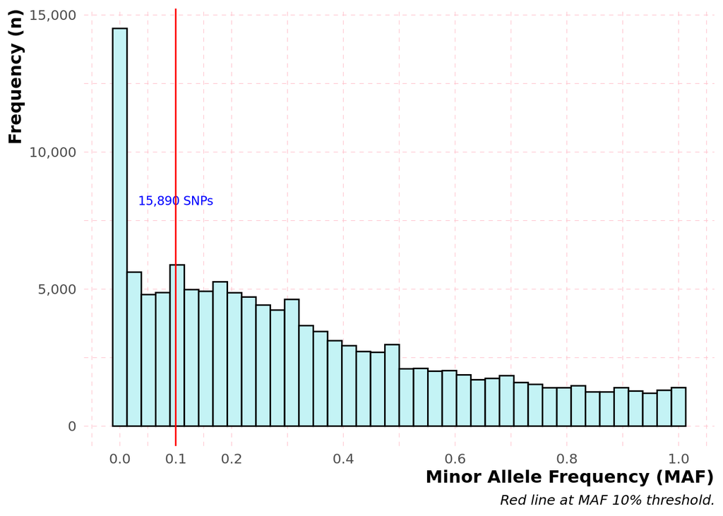

```r
ggplot(
  maf_freq,
  aes(ALT_FREQS)
) +
  geom_histogram(
    colour = "black",
    fill = "#C4F3F5",
    bins = 40
  ) +
  labs(
    x = "Minor Allele Frequency (MAF)",
    y = "Frequency (n)",
    caption = "Red line at MAF 10% threshold."
  ) +
  annotate(
    "text",
    x = .1,
    y = 8000,
    label = "15,890 SNPs",
    size = 3,
    color = "blue",
    vjust = -.2
  ) +
  geom_vline(xintercept = 0.1, color = "red") +
  my_theme() +
  theme(plot.caption = element_text(face = "italic")) +
  scale_y_continuous(label = scales::number_format(big.mark = ",")) +
  scale_x_continuous(breaks = c(0, 0.1, 0.2, 0.4, 0.6, 0.8, 1))
```

```r
ggsave(
  here(
    "output", "quality_control", "figures", "MAF.pdf"
  ),
  width  = 5,
  height = 4,
  units  = "in"
)
```

Now we apply the MAF filter.

```bash
plink2 \
--allow-extra-chr \
--bfile output/quality_control/file3 \
--maf 0.01 \
--make-bed \
--out output/quality_control/file4 \
--silent;
grep "variants" output/quality_control/file4.log
```

```
## 127110 variants loaded from output/quality_control/file3.bim.
## 15890 variants removed due to allele frequency threshold(s)
## 111220 variants remaining after main filters.
```

HWE was tested per population following Marees et al. (2018).

```bash
mkdir -p output/quality_control/hardy;
cp output/quality_control/file4.* output/quality_control/hardy/
```

## 3.3 HWE test

HWE was tested per population with a p-value threshold of 1e-6. SNP missingness was re-applied within each population to stabilize HWE estimates.

```bash
for fam in $(awk '{print $1}' output/quality_control/hardy/file4.fam | sort | uniq);
do
echo $fam | \
plink2 \
--allow-extra-chr \
--silent \
--keep-allele-order \
--bfile output/quality_control/hardy/file4 \
--keep-fam /dev/stdin \
--make-bed \
--out output/quality_control/hardy/$fam \
--hwe 0.000001 \
--geno 0.1 \
--write-snplist; \
done
```

```bash
cat output/quality_control/hardy/*.snplist | awk '!a[$0]++' > output/quality_control/passed_hwe.txt;
wc -l output/quality_control/passed_hwe.txt
```

```
## 110353 output/quality_control/passed_hwe.txt
```

How many variants we had before

```bash
cat output/quality_control/file4.bim | awk '{print $2}'| awk '!a[$0]++' | wc -l
```

```
## 111220
```

Variants not passing HWE test

```r
111220 - 110353
```

```
## [1] 867
```

Remove the SNPs that failed

```bash
plink2 \
--allow-extra-chr \
--bfile output/quality_control/file4 \
--extract output/quality_control/passed_hwe.txt \
--make-bed \
--out output/quality_control/file4a \
--silent;
grep "variants" output/quality_control/file4a.log
```

```
## 111220 variants loaded from output/quality_control/file4.bim.
## --extract: 110353 variants remaining.
## 110353 variants remaining after main filters.
```

## 3.4 LD pruning

```bash
plink2 \
--allow-extra-chr \
--bfile output/quality_control/file4a \
--indep-pairwise 5 1 0.1 \
--out output/quality_control/indepSNP \
--silent;
grep 'pairwise\|variants\|samples' output/quality_control/indepSNP.log
```

```
##   --indep-pairwise 5 1 0.1
## 61 samples (25 females, 26 males, 10 ambiguous; 61 founders) loaded from
## 110353 variants loaded from output/quality_control/file4a.bim.
## --indep-pairwise (11 compute threads): 68504/110353 variants removed.
```

## 3.6 Heterozygosity

```bash
plink2 \
--allow-extra-chr \
--bfile output/quality_control/file4a \
--extract output/quality_control/indepSNP.prune.in \
--het \
--out output/quality_control/R_check \
--silent;
grep 'variants' output/quality_control/R_check.log
```

```
## 110353 variants loaded from output/quality_control/file4a.bim.
## --extract: 41849 variants remaining.
## 41849 variants remaining after main filters.
```

```r
het <- read.delim(
  here(
    "output", "quality_control", "R_check.het"
  ),
  head = TRUE
)
colnames(het)
```

```
## [1] "X.FID"  "IID"    "O.HOM." "E.HOM." "OBS_CT" "F"
```

Heterozygosity rate was calculated per individual. Individuals deviating more than 4 SD from the mean were flagged.

```r
het$HET_RATE <- (het$"OBS_CT" - het$"O.HOM") / het$"OBS_CT"

het_fail <-
  subset(
    het, (het$HET_RATE < mean(
      het$HET_RATE
    ) - 4 * sd(
      het$HET_RATE
    )) |
      (het$HET_RATE > mean(
        het$HET_RATE
      ) + 4 * sd(
        het$HET_RATE
      ))
  )

het_fail$HET_DST <-
  (het_fail$HET_RATE - mean(
    het$HET_RATE
  )) / sd(
    het$HET_RATE
  )
```

```r
write.table(
  het_fail,
  here(
    "output", "quality_control", "fail-het-qc.txt"
  ),
  row.names = FALSE
)
```

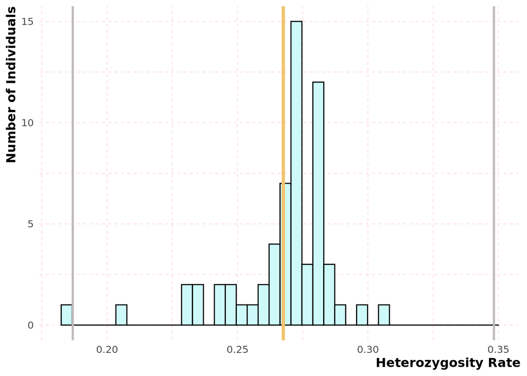

```r
ggplot(
  het,
  aes(
    HET_RATE
  )
) +
  geom_histogram(
    colour           = "black",
    fill             = "#CDFAF8",
    bins             = 40
  ) +
  labs(
    x                = "Heterozygosity Rate",
    y                = "Number of Individuals"
  ) +
  geom_vline(
    aes(
      xintercept     = mean(
        HET_RATE
      )
    ),
    col              = "#F2C46F",
    linewidth        = 1.5
  ) +
  geom_vline(
    aes(
      xintercept     = mean(
        HET_RATE
      ) + 4 * sd(
        HET_RATE
      )
    ),
    col              = "#BFB9B9",
    linewidth        = 1
  ) +
  geom_vline(
    aes(
      xintercept     = mean(
        HET_RATE
      ) - 4 * sd(
        HET_RATE
      )
    ),
    col              = "#BFB9B9",
    linewidth        = 1
  ) +
  my_theme() +
  scale_y_continuous(
    labels           = comma
  )
```

```r
ggsave(
  here(
    "output", "quality_control", "figures", "Heterozygosity.pdf"
  ),
  width  = 5,
  height = 4,
  units  = "in"
)
```

The orange line indicates the mean; gray lines indicate +/- 4 SD. Individuals identified as outliers were listed for removal.

```bash
sed 's/"// g' output/quality_control/fail-het-qc.txt | awk '{print$1, $2}'> output/quality_control/het_fail_ind.txt;
echo 'How many mosquitoes we need to remove from our data set:';
cat output/quality_control/het_fail_ind.txt | tail -n +2 | wc -l;
echo 'Which mosquitoes we have to remove:';
tail -n +2 output/quality_control/het_fail_ind.txt
```

```
## How many mosquitoes we need to remove from our data set:
## 1
## Which mosquitoes we have to remove:
## AUT 399
```

Heterozygosity outliers were removed:

```bash
plink2 \
--allow-extra-chr \
--bfile output/quality_control/file4a \
--remove output/quality_control/het_fail_ind.txt \
--make-bed \
--out output/quality_control/file5 \
--silent;
grep 'variants\|samples' output/quality_control/file5.log
```

```
## 61 samples (25 females, 26 males, 10 ambiguous; 61 founders) loaded from
## 110353 variants loaded from output/quality_control/file4a.bim.
## --remove: 60 samples remaining.
## 60 samples (24 females, 26 males, 10 ambiguous; 60 founders) remaining after
```

## 3.7 Relatedness

Cryptic relatedness was assessed with KING kinship coefficients (Manichaikul et al. 2010). KING coefficients are scaled such that duplicate samples have kinship 0.5, first-degree relations ~0.25, and second-degree relations ~0.125. A cutoff of 0.354 (geometric mean of 0.5 and 0.25) was used to screen for duplicates.

```bash
plink2 \
--allow-extra-chr \
--bfile output/quality_control/file5 \
--extract output/quality_control/indepSNP.prune.in \
--make-king-table rel-check \
--king-table-filter 0.354 \
--out output/quality_control/file5a \
--silent;
grep 'variants\|samples' output/quality_control/file5a.log
```

```
## 60 samples (24 females, 26 males, 10 ambiguous; 60 founders) loaded from
## 110353 variants loaded from output/quality_control/file5.bim.
## --extract: 41849 variants remaining.
## 41849 variants remaining after main filters.
```

Individuals flagged by the KING relatedness filter:

```bash
head output/quality_control/file5a.kin0
```

```
## #FID1    IID1    FID2    IID2    NSNP    HETHET  IBS0    KINSHIP
```

No related individuals were found.

```bash
plink2 \
--allow-extra-chr \
--bfile output/quality_control/file5 \
--extract output/quality_control/indepSNP.prune.in \
--make-king triangle bin \
--out output/quality_control/file6 \
--silent;
grep 'variants\|samples' output/quality_control/file6.log
```

```
## 60 samples (24 females, 26 males, 10 ambiguous; 60 founders) loaded from
## 110353 variants loaded from output/quality_control/file5.bim.
## --extract: 41849 variants remaining.
## 41849 variants remaining after main filters.
## --make-king pass 1/1: Scanning for rare variants... done.
## 1245 variants handled by initial scan (40604 remaining).
## --make-king: 41849 variants processed.
```

PLINK2 removed related individuals while maximizing sample retention.

```bash
plink2 \
--allow-extra-chr \
--bfile output/quality_control/file5 \
--king-cutoff output/quality_control/file6 0.354 \
--make-bed \
--out output/quality_control/file7 \
--silent;
grep 'samples\|variants\|remaining' output/quality_control/file7.log
```

```
## 60 samples (24 females, 26 males, 10 ambiguous; 60 founders) loaded from
## 110353 variants loaded from output/quality_control/file5.bim.
## output/quality_control/file7.king.cutoff.out.id , and 60 remaining sample IDs
```

```bash
head -n 10 output/quality_control/file7.king.cutoff.out.id
```

```
## #FID IID
```

No individuals were removed due to relatedness.

```bash
plink2 \
--allow-extra-chr \
--bfile output/quality_control/file7 \
--pca allele-wts \
--freq \
--out output/quality_control/pca_pops \
--silent;
grep 'samples\|variants' output/quality_control/pca_pops.log
```

```
## 60 samples (24 females, 26 males, 10 ambiguous; 60 founders) loaded from
## 110353 variants loaded from output/quality_control/file7.bim.
```

```r
pca <- read.delim(
  here(
    "output", "quality_control", "pca_pops.eigenvec"
  ),
  head = TRUE
)

head(pca)
```

```
##   X.FID IID        PC1        PC2        PC3         PC4        PC5        PC6
## 1   MAN 306 -0.0913239 -0.0883668 -0.1575640  0.03060270  0.0736423 -0.0966122
## 2   MAN 307 -0.1165830 -0.1604110 -0.1928870  0.00426111 -0.0392307 -0.1805130
## 3   MAN 308 -0.1092400 -0.1071860 -0.1721780 -0.00431477  0.0581054 -0.4130700
## 4   MAN 309 -0.1105640 -0.1247490 -0.1573170 -0.00275033  0.0039986 -0.0441429
## 5   MAN 310 -0.0691896 -0.0441948 -0.0806318  0.19202600 -0.0199620  0.0510735
## 6   MAN 311 -0.0899829 -0.1201360 -0.1003930  0.01009320 -0.0576055  0.0219653
##            PC7       PC8        PC9       PC10
## 1  0.019931800 -0.220985  0.1620490  0.0959124
## 2 -0.000233315  0.233686 -0.1521200 -0.0316382
## 3  0.019968600  0.168698 -0.1586580  0.0386871
## 4  0.010466500 -0.225898  0.1217150  0.0941331
## 5 -0.000256229  0.140714  0.0297651 -0.2804500
## 6 -0.023091400 -0.230319 -0.0835833 -0.2497100
```

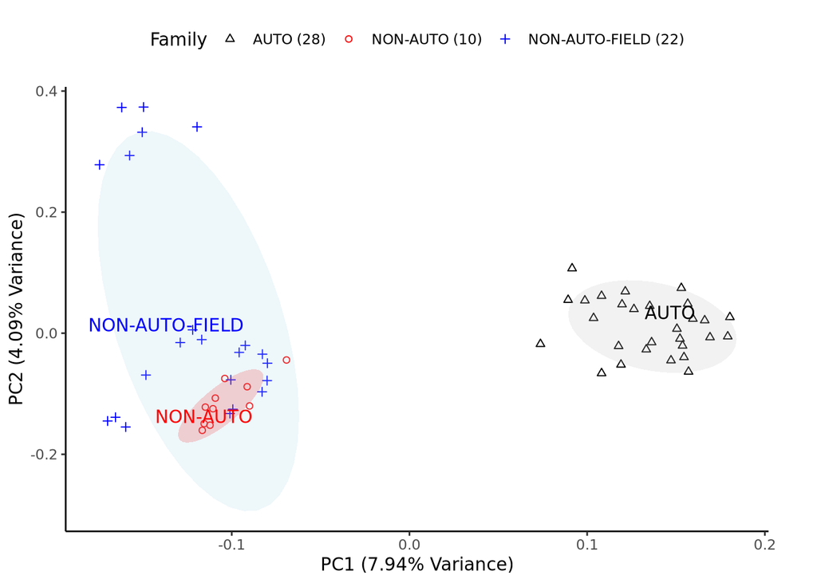

```r
# Shapes
N = 100
M = 1000
good.shapes = c(1:25, 33:127)

# Colors
palette1 <- brewer.pal(12, "Paired")
palette2 <- brewer.pal(11, "Set3")
palette23 <- c(palette1, palette2)

# Recode population labels to manuscript names
pca$X.FID <- recode(pca$X.FID,
  "AUT" = "AUTO", "MAN" = "NON-AUTO", "NEW" = "NON-AUTO-FIELD")

# Compute the count
family_count <- pca |>
  group_by(X.FID) |>
  summarize(count = n())

# Merge the count back to the main data
df4 <- pca |>
  left_join(family_count, by = "X.FID")

# Create a custom label for the legend
df4$family_label <-
  paste(df4$X.FID, " (", df4$count, ")", sep = "")

# Define the color and shape manually
palette23 <- c(palette1, palette2)
colors <- setNames(palette23, unique(df4$family_label))
shapes <-
  setNames(good.shapes[c(1:25, 58:67)], unique(df4$family_label))


# Compute the center of ellipses for each continent
ellipse_centers <- df4 |>
  group_by(X.FID) |>
  summarise(PC1_center = mean(PC1), PC2_center = mean(PC2))

# Create the plot
ggplot(df4, aes(PC1, PC2)) +
  geom_point(aes(shape = family_label, color = family_label)) +
  stat_ellipse(
    aes(fill = X.FID, group = X.FID),
    geom = "polygon",
    alpha = 0.2,
    level = 0.8,
    segments = 40,
    color = "transparent",
    show.legend = FALSE
  ) +
  geom_text_repel(
    data = ellipse_centers,
    aes(x = PC1_center, y = PC2_center, label = X.FID),
    color = c("black", "red", "blue")
  ) +
  xlab("PC1 (7.94% Variance)") +
  ylab("PC2 (4.09% Variance)") +
  guides(
  color = guide_legend(title = "Family", order = 1, ncol = 3),
  shape = guide_legend(title = "Family", order = 1, ncol = 3),
  fill = guide_legend(title = "Family", order = 1, ncol = 3)
  ) +
  scale_fill_manual(values = c("gray", "red", "lightblue"), labels = df4$family_label) +
  scale_color_manual(values = c("black", "red", "blue")) +
  scale_shape_manual(values = shapes) +
  theme_classic() +
  theme(
    plot.caption = element_text(face = "italic"),
    legend.position = "top",
    legend.direction = "horizontal",
    legend.justification = "center",
    legend.box.just = "center",
    legend.box.background = element_blank(),
    plot.margin = margin(5.5, 30, 5.5, 5.5, "points"),
    legend.margin = margin(10, 10, 10, 10)
)
```

```r
ggsave(
  here(
    "output", "quality_control", "figures", "PCA_plink.pdf"
  ),
  width  = 7,
  height = 5,
  units  = "in"
)
```

```r
objects <- ls()
save(list = objects, file = here(
    "output", "quality_control", "figures", "pca.RData"
  ))
```

## 4. Create chromosomal scale

Import the .bim file with the SNPs to create a new chromosomal scale.

```r
snps <-
  read_delim(
    here(
      "output", "quality_control", "file7.bim"
    ),
    col_names      = FALSE,
    show_col_types = FALSE,
    col_types      = "ccidcc"
  )

colnames(snps) <- c("Scaffold", "SNP", "Cm", "Position", "Allele1", "Allele2")

head(snps)
```

```
## # A tibble: 6 x 6
##   Scaffold SNP             Cm Position Allele1 Allele2
##   <chr>    <chr>        <int>    <dbl> <chr>   <chr>
## 1 1.1      AX-581444870     0    97856 C       T
## 2 1.1      AX-583035083     0   305518 A       G
## 3 1.1      AX-583035102     0   308124 A       G
## 4 1.1      AX-583033342     0   315059 C       G
## 5 1.1      AX-583035163     0   315386 A       G
## 6 1.1      AX-583033356     0   315674 C       T
```

SNP data were separated by chromosome.

```r
chr_snps_list <- list()
for (chr in c("1", "2", "3")) {
  chr_snps_list[[chr]] <- snps |>
    filter(str_detect(Scaffold, paste0("^", chr, "\\."))) |>
    as_tibble()
}
```

The reference genome was indexed with samtools.

```bash
# index the genome
samtools faidx data/genome/albo.fasta.gz
```

Scaffold sizes were extracted from the `.fai` index file.

```bash
awk 'BEGIN{FS=" "; OFS="\t"} {print $1, $2}' data/genome/albo.fasta.gz.fai > data/genome/scaffold_sizes.txt;
head data/genome/scaffold_sizes.txt
```

```
## 1.1  351198
## 1.10 11939576
## 1.100    3389100
## 1.101    470438
## 1.102    2525157
## 1.103    150026
## 1.104    51905
## 1.105    662742
## 1.106    7592381
## 1.107    204538
```

Import the file with sizes of each scaffold.

```r
sizes <-
  read_delim(
    here(
      "data", "genome", "scaffold_sizes.txt"
    ),
    col_names      = FALSE,
    show_col_types = FALSE,
    col_types      = "cd"
  )

colnames(sizes) <- c("Scaffold", "Size")

sizes <-
  sizes |>
  mutate(
    Chromosome = case_when(
      startsWith(Scaffold, "1") ~ "1",
      startsWith(Scaffold, "2") ~ "2",
      startsWith(Scaffold, "3") ~ "3"
    )
  ) |>
  arrange(Scaffold)

head(sizes)
```

```
## # A tibble: 6 x 3
##   Scaffold     Size Chromosome
##   <chr>       <dbl> <chr>
## 1 1.1        351198 1
## 2 1.10     11939576 1
## 3 1.100     3389100 1
## 4 1.101      470438 1
## 5 1.102     2525157 1
## 6 1.103      150026 1
```

Create new scale. Get the scaffolds for each chromosome.

```r
chr_scaffolds_list <- list()
for (chr in c("1", "2", "3")) {
  chr_scaffolds_list[[chr]] <- sizes |>
    filter(str_detect(Scaffold, paste0("^", chr))) |>
    as_tibble()
}
```

Create a scale for each chromosome.

```r
for (chr in c("1", "2", "3")) {
  chr_scaffolds_list[[chr]]$overall_size_before_bp <- 0
  for (i in 2:nrow(chr_scaffolds_list[[chr]])) {
    chr_scaffolds_list[[chr]]$overall_size_before_bp[i] <-
      chr_scaffolds_list[[chr]]$overall_size_before_bp[i - 1] +
      chr_scaffolds_list[[chr]]$Size[i - 1]
  }
}
```

Merge the data frames scaffolds and SNPs.

```r
chr_scale_list <- list()
for (chr in c("1", "2", "3")) {
  chr_scale_list[[chr]] <- chr_snps_list[[chr]] |>
    left_join(chr_scaffolds_list[[chr]], by = "Scaffold") |>
    na.omit() |>
    mutate(
      midPos_fullseq = as.numeric(Position) + as.numeric(overall_size_before_bp)
    )
}
```

Merge all chromosome scales.

```r
chroms <- bind_rows(chr_scale_list) |>
  dplyr::select(
    Chromosome, SNP, Cm, midPos_fullseq, Allele1, Allele2
  )
head(chroms)
```

```
## # A tibble: 6 x 6
##   Chromosome SNP             Cm midPos_fullseq Allele1 Allele2
##   <chr>      <chr>        <int>          <dbl> <chr>   <chr>
## 1 1          AX-581444870     0          97856 C       T
## 2 1          AX-583035083     0         305518 A       G
## 3 1          AX-583035102     0         308124 A       G
## 4 1          AX-583033342     0         315059 C       G
## 5 1          AX-583035163     0         315386 A       G
## 6 1          AX-583033356     0         315674 C       T
```

```r
write.table(
  chroms,
  file      = here(
    "output", "quality_control", "file7B.bim"
  ),
  sep       = "\t",
  row.names = FALSE,
  col.names = FALSE,
  quote     = FALSE
)
```

Rename the .bim files

```bash
mv output/quality_control/file7.bim output/quality_control/file7_backup.bim;
mv output/quality_control/file7B.bim output/quality_control/file7.bim
```

Validation check with PLINK2 to confirm variant ordering:

```bash
plink2 \
--bfile output/quality_control/file7 \
--make-bed \
--out output/quality_control/test01;
rm output/quality_control/test01.*
```

```
## PLINK v2.0.0-a.6.9LM 64-bit Intel (29 Jan 2025)    cog-genomics.org/plink/2.0/
## (C) 2005-2025 Shaun Purcell, Christopher Chang   GNU General Public License v3
## Logging to output/quality_control/test01.log.
## Options in effect:
##   --bfile output/quality_control/file7
##   --make-bed
##   --out output/quality_control/test01
##
## Start time: Sun Apr  5 23:08:42 2026
## 32011 MiB RAM detected, ~26062 available; reserving 16005 MiB for main
## workspace.
## Using up to 12 threads (change this with --threads).
## 60 samples (24 females, 26 males, 10 ambiguous; 60 founders) loaded from
## output/quality_control/file7.fam.
## 110353 variants loaded from output/quality_control/file7.bim.
## 1 binary phenotype loaded (28 cases, 22 controls).
## Writing output/quality_control/test01.fam ... done.
## Writing output/quality_control/test01.bim ... done.
## Writing output/quality_control/test01.bed ... 0%59%done.
## End time: Sun Apr  5 23:08:42 2026
```

No warnings from PLINK2.

## 5. Plot SNP density

After quality control with 110,353 SNPs

```r
snp_den_qc <- import_bim(
  here(
    "output", "quality_control", "file7.bim"
  )
)
```

Make plot of the SNP density

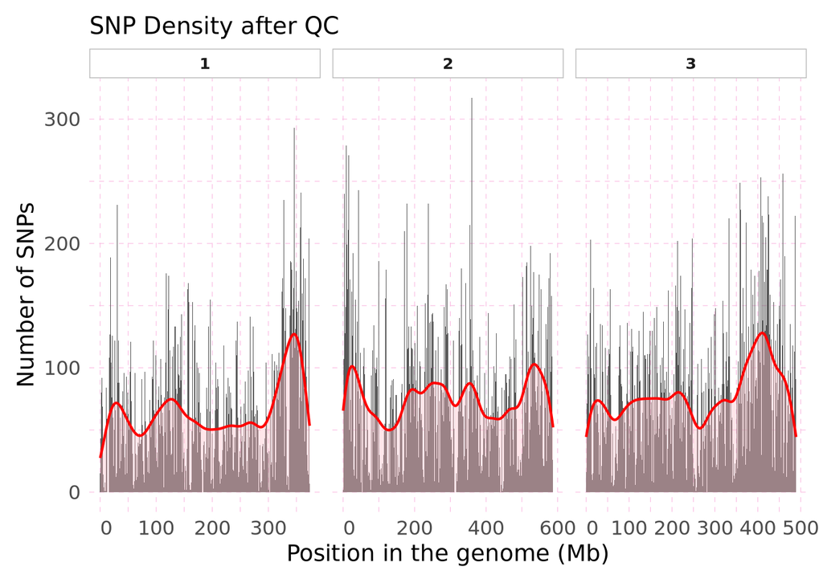

```r
snp_den_qc |>
  rename(
    Chromosome = 1
  ) |>
  mutate(
    Position           = as.numeric(
      Position
    )
  ) |>
  ggplot(
    aes(
      x                = Position
    )
  ) +
  geom_histogram(
    aes(
      y                = after_stat(
        count
      )
    ),
    binwidth           = 1e6
  ) +
  facet_wrap(
    vars(
      Chromosome
    ),
    scales             = "free_x"
  ) +
  labs(
    title              = "SNP Density after QC",
    x                  = expression(
      "Position in the genome (Mb)"
    ),
    y                  = expression(
      "Number of SNPs"
    )
  ) +
  scale_x_continuous(
    labels             = function(x) {
      format(
        x / 1e6,
        big.mark       = ",",
        scientific     = FALSE
      )
    }
  ) +
  geom_density(
  aes(
    y = 1e6 * after_stat(count)
  ),
  color = "red",
  linewidth = .75,
  alpha = .4,
  fill = "pink"
  ) +
  theme_minimal(
    base_size          = 12
  ) +
  theme(
    panel.grid.major   = element_line(
      linetype         = "dashed",
      linewidth        = 0.2,
      color            = "#fabbe2"
    ),
    panel.grid.minor   = element_line(
      linetype         = "dashed",
      linewidth        = 0.2,
      color            = "#fabbe2"
    ),
    panel.spacing      = unit(0.5, "lines"),
    strip.text         = element_text(
      face             = "bold", hjust = .5
    ),
    strip.background.x = element_rect(
      color            = "gray"
    ),
    plot.margin        = margin(10, 10, 10, 10),
    axis.text          = element_text(size = 12),
    axis.title         = element_text(size = 14)
  )
```

```r
ggsave(
  here(
    "output", "quality_control","figures", "snp_density_after_qc.pdf"
  ),
  width  = 10,
  height = 6,
  units  = "in"
)
```

SNPs per chromosome

```r
snps_per_chrm <-
  snp_den_qc |>
  count(
    Scaffold) |>
  rename(
    Chromosome = 1,
    "SNPs (N) " = 2
  )

knitr::kable(snps_per_chrm, caption = "SNPs per chromosome after quality control")
```

SNPs per chromosome after quality control

| Chromosome | SNPs (N) |
| --- | --- |
| 1 | 25105 |
| 2 | 45902 |
| 3 | 39346 |

Mean SNP density per 1 Mb window by chromosome:

```r
albo_den <-
  snp_den_qc |>
  dplyr::select(
    Scaffold, Position
  ) |>
  group_by(
    Scaffold,
    windows               = cut_width(
      Position,
      width               = 1e6,
      boundary            = 0
    )
  ) |>
  summarise(
    n                     = n(),
    .groups               = "keep"
  ) |>
  group_by(
    Scaffold
  ) |>
  summarise(
    mean                  = mean(n),
    n                     = n(),
    .groups               = "keep"
  ) |>
  rename(
    Chromosome            = 1,
    "SNPs per 1Mb window" = 2,
    "Number of windows"   = 3
  )
knitr::kable(albo_den, caption = "SNPs per 1Mb window")
```

SNPs per 1Mb window

| Chromosome | SNPs per 1Mb window | Number of windows |
| --- | --- | --- |
| 1 | 67.85135 | 370 |
| 2 | 79.00516 | 581 |
| 3 | 80.46217 | 489 |

```r
after_qc <-
  snps_per_chrm |>
  left_join(
    albo_den,
    by = "Chromosome"
  )
knitr::kable(after_qc, caption = "QC summary per chromosome")
```

QC summary per chromosome

| Chromosome | SNPs (N) | SNPs per 1Mb window | Number of windows |
| --- | --- | --- | --- |
| 1 | 25105 | 67.85135 | 370 |
| 2 | 45902 | 79.00516 | 581 |
| 3 | 39346 | 80.46217 | 489 |

## 6. Create data sets for downstream analysis

Population subsets were created for pairwise comparisons (see label key in Section 1).

```bash
echo "MAN
AUT" > output/quality_control/man_aut.txt;
echo "NEW
AUT" > output/quality_control/new_aut.txt;
echo "MAN
NEW" > output/quality_control/man_new.txt
echo "AUT" > output/quality_control/aut.txt
```

VCF and BED files were created for each pairwise comparison using LD-pruned data.

MAN vs AUT

```bash
plink2 \
--bfile output/quality_control/file7 \
--keep-fam output/quality_control/man_aut.txt \
--export vcf \
--extract output/quality_control/indepSNP.prune.in \
--make-bed \
--geno 0.2 \
--out output/outflank/man_aut \
--silent;
grep "samples\|variants" output/outflank/man_aut.log
```

```
## 60 samples (24 females, 26 males, 10 ambiguous; 60 founders) loaded from
## 110353 variants loaded from output/quality_control/file7.bim.
## --extract: 41849 variants remaining.
## --keep-fam: 38 samples remaining.
## 38 samples (13 females, 15 males, 10 ambiguous; 38 founders) remaining after
## --geno: 517 variants removed due to missing genotype data.
## 41332 variants remaining after main filters.
```

NEW vs AUT

```bash
plink2 \
--bfile output/quality_control/file7 \
--keep-fam output/quality_control/new_aut.txt \
--export vcf \
--extract output/quality_control/indepSNP.prune.in \
--make-bed \
--geno 0.2 \
--out output/outflank/new_aut \
--silent;
grep "samples\|variants" output/outflank/new_aut.log
```

```
## 60 samples (24 females, 26 males, 10 ambiguous; 60 founders) loaded from
## 110353 variants loaded from output/quality_control/file7.bim.
## --extract: 41849 variants remaining.
## --keep-fam: 50 samples remaining.
## 50 samples (24 females, 26 males; 50 founders) remaining after main filters.
## --geno: 153 variants removed due to missing genotype data.
## 41696 variants remaining after main filters.
```

MAN vs NEW

```bash
plink2 \
--bfile output/quality_control/file7 \
--keep-fam output/quality_control/man_new.txt \
--export vcf \
--extract output/quality_control/indepSNP.prune.in \
--make-bed \
--geno 0.2 \
--out output/outflank/man_new \
--silent;
grep "samples\|variants" output/outflank/man_new.log
```

```
## 60 samples (24 females, 26 males, 10 ambiguous; 60 founders) loaded from
## 110353 variants loaded from output/quality_control/file7.bim.
## --extract: 41849 variants remaining.
## --keep-fam: 32 samples remaining.
## 32 samples (11 females, 11 males, 10 ambiguous; 32 founders) remaining after
## --geno: 643 variants removed due to missing genotype data.
## 41206 variants remaining after main filters.
```

AUT

```bash
plink2 \
--bfile output/quality_control/file7 \
--keep-fam output/quality_control/aut.txt \
--export vcf \
--extract output/quality_control/indepSNP.prune.in \
--make-bed \
--geno 0.2 \
--out output/outflank/aut \
--silent;
grep "samples\|variants" output/outflank/aut.log
```

```
## 60 samples (24 females, 26 males, 10 ambiguous; 60 founders) loaded from
## 110353 variants loaded from output/quality_control/file7.bim.
## --extract: 41849 variants remaining.
## --keep-fam: 28 samples remaining.
## 28 samples (13 females, 15 males; 28 founders) remaining after main filters.
## --geno: 844 variants removed due to missing genotype data.
## 41005 variants remaining after main filters.
```